# Optimization

# Optimization

Selecting parameters that maximize or minimize something

- if that something is model performance its a form of calibration
- sometimes its finding parameter values that push the system to a desirable state

Examples?

# Optimization

Optimization requres that you define..

- the *objective/output* that you want to minimize or maximize
- the *parameters* (or inputs) that you can “play” with to change the output
- the *model* (or set of models) that define the relationship between the output and the parameters

# Optimization

[figure not shown]

[figure not shown]

# Optimization

*Objective* what you want to maximize or minimize based on your output variable (or some transformation of it)

the output variable may be multi-dimensional if you are trying to minimize two or more things at the same time

- minimize energy use and water use
- maximize profit and minimize energy use

# Optimization

Objectives using two or more variables

**Pareto optimality**

point where any change in one variable will reduce objective for the other variable (balancing your multiple objectives)

One option - define an objective function (single variable) that combines the two variables useful because you can decide on the weighting

- 0.5*energy.use + 0.5*cost
- 0.8*energy.use + 0.2*cost

make sure that energy.use and costs are relative values to that it makes sense to add them

alot like developing *performance metrics* (performance metrics are a type of objective function)

# Optimization

*Parameters*

You can have more than one “free” parameters - parameters that you can vary to minimize or maximize your objective

- minimizing energy use by changing both time of day that a factory functions and the operating temperature
- minimizing air pollution by reducing the number of drivers and the time spent driving
- maximizing species richness by increasing fire frequency and reducing fire severity

# Optimization

Two free parameters - Minimize energy use as a function of temperature AND type of substrate/material

[

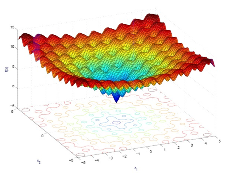

]

# Optimization

How easy the optimization is depends on the model - or the functional relationship between free parameters and the objective function

Three possibilities

- the minimum can be derived mathematically
- you can graph the relationships and “see” the minimum
- you get there by trial and error - we have very sophisticated ways of doing the “trial and error”

# Optimization Example

**When should a farmer harvest given a model of changing export prices for rice**

[Example of optimization of waiting times for food profit maximization](http://derivative-functions.cours-de-math.eu/advanced-math-english14.php)

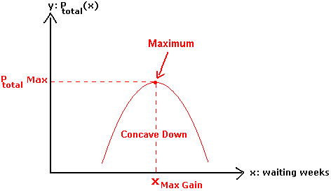

Finding the “optimal” value of the parameter (waiting weeks) and the value of the objective function (price) at the optimum is visually easy to assess

# Key Optimization Challenge

Avoiding local minimum and maximum

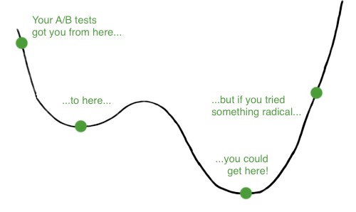

Similar to why we use Sobel to search parameter space [non-local minuimum more detail](http://www.smashingmagazine.com/2010/08/26/in-defense-of-a-b-testing/)

Optimization approaches vary in terms of ability * to find non-local optima * ability to handle multiple criteria]

# Optimization

[figure not shown]

www.mathworks.com

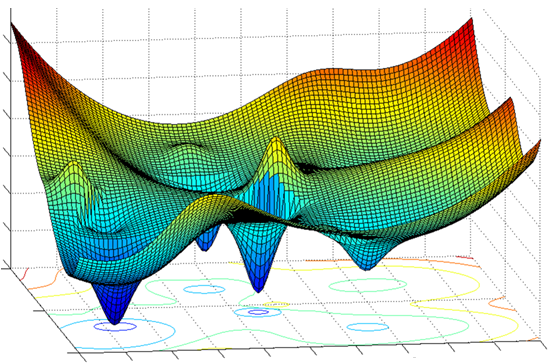

www.mathworks.com

# Optimization Techniques

Math geeks and engineers have developed all kinds of strategies for search parameter spaces to find minimum, that deal with complex spaces with lots non-local minimum

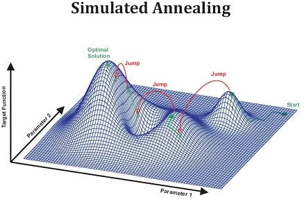

# Optimization

One more distinction

- Constrained vs unconstrained unconstrained …what we’ve been looking at
- Constrained….add rules about what parameters can be selected (e.g you must purchase at least 20 units of x)

# Optimization

Optimization of more complex models - almost always requires one of these “search” techniques

- think about coming up with the optimal sea wall size in coastal flooding model

# Optimization in R

Different R functions available that help with automate the “searching” for you

- dealing with multi-dimensional search spaces
- dealing with complex (multi-min, multi-max) search spaces
- constrained/unconstrained

# Optimization in R

If you can solve it mathematically/visually then do so - you can use math/graphs to find the optimal value

If not R can help you do that two steps

1. code your model as a function
2. send function, and parameters to the optimizer
3. the optimizer searches for a minimum value of the model output

# Optimization in R

*Optimize* (function to be minimized, lower bound, upper bound..)

Can also provide:

- tol - tolerance (how close do you have to get )
- maximum - if maximum=T, finds the maximum; default is finding the minimum

# Simple Example

Pollution output as a function of temperature

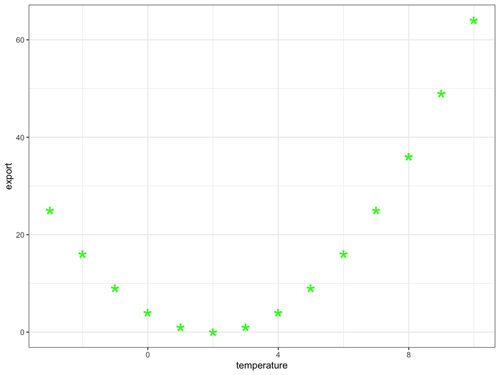

```r
pollutant_export = function(temperature) {
        result =( (temperature-2)**2)
                return(result)
        }

temps = seq(from=-3,to=10)

pollution = data.frame(temperature=temps, export=pollutant_export(temps))
ggplot(pollution, aes(temperature,export))+geom_point( col="green", size=10, pch="*")+theme_bw()
```

What temperature minimizes pollutant export?

Easy to see from graph

# Optimize in R - Simple example

Even though we can solve visually lets try to use optimize anyway

*optimize*

requires function to be minimized, lower and upper bounds of parameter, and tolerance (optional)

tolerance is how close do you need to get to minimum

Returns parameter value that gives the minimum and how close you got

```r
result=optimize(pollutant_export, lower=-3, upper=10)
result
```

```
## $minimum
## [1] 2
##
## $objective
## [1] 0
```

# Optimization in R - a more complex example

Lets say we have an option to purchase irrigation water; the contract requires us to commit to purchasing the irrigation water for a number of years in the future; we want to know how much irrigation water to purchase to maximize our profit from growing almonds (or some other crop)

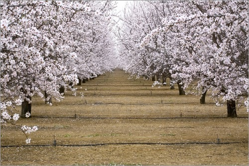

# Optimization in R

What we have

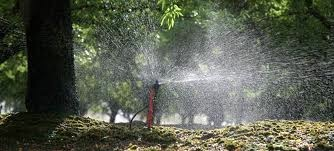

# Combined models

Lets return to a model of crop yields - we have a new model - in compute_yield that includes the impact of irrigation on yields, given some crop parameters and precipitation and temperature

**compute_yield**

We also have a model of profit that accounts for price of the crop and costs of irrigation

**compute_profit**

What is the optimal irrigation amount given price of crop and cost of irrigation?

We can use **optimize** here - leave one input or parameter “free” - e.g use for upper and lower bounds in the optimation

We will keep irrigation “free”

```r
source("../R/compute_profit.R")
source("../R/compute_yield.R")
source("../R/compute_NPV.R")

crop_pars = c(ts=0.4, tp=0.5, base.yield=500, Topt=25, max.water=800)

# lets assume water cost $150 per mm/yr (depth of water per crop area)
optimize(compute_profit, lower=0, upper=400, T=c(20,30,25), P=c(250,144,100), discount=0.01, price=50, cost=150, crop.pars=crop_pars,  maximum=TRUE)
```

```
## $maximum
## [1] 4.143114e-05
##
## $objective
## [1] 85471.24
```

```r
# try with cheaper water
optimize(compute_profit, lower=0, upper=400, T=c(20,30,25), P=c(250,144,100), discount=0.01, price=50, cost=25, crop.pars=crop_pars,  maximum=TRUE)
```

```
## $maximum
## [1] 319.0439
##
## $objective
## [1] 85471.25
```

You can run your optimization for a range of water prices

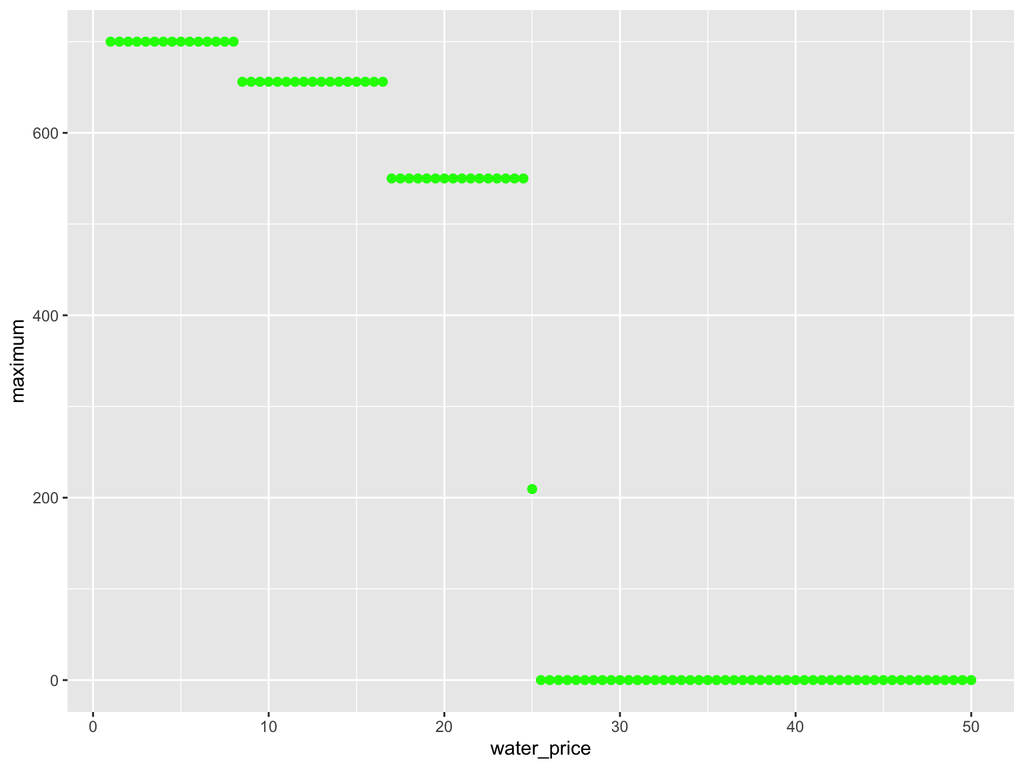

```r
water_price=seq(from=1, to=50, by=0.5)

# use map to run optimization for different water prices
# lets also broaden our irrigation range
result = water_price %>% map_df(~optimize(compute_profit, lower=0, upper=1000, T=c(20,30,25), P=c(250,144,100), discount=0.01, price=50, cost=.x, crop.pars=crop_pars,  maximum=TRUE))

# add water price to result
result$water_price = water_price

# graph the results
ggplot(result, aes(water_price, maximum))+geom_point(col="green", size=2)
```

```r
# how could you do this for a range of prices for crops
```